# Assignment_2_Isabel_Li

Isabel Li

2024-02-13

# Installation of packagages if neccessary

```r
if(!requireNamespace('htmltools', quietly = TRUE))
  install.packages('htmltools')


if(!requireNamespace('colorRamp2', quietly = TRUE))
  install.packages('colorRamp2')


if (!requireNamespace("BiocManager", quietly = TRUE)){
  install.packages("BiocManager")}


if(!requireNamespace('dplyr', quietly = TRUE))
  tidyr::install("dplyr")


if(!requireNamespace("kableExtra", quietly = TRUE))
  install.packages("kableExtra")


if(!requireNamespace("limma", quietly = TRUE))
    BiocManager::install("limma")

if(!requireNamespace('edgeR', quietly = TRUE))
  install.packages('edgeR')


if(!requireNamespace('ggplot2', quietly = TRUE))
  install.packages('ggplot2')

if(!requireNamespace('ggpubr', quietly = TRUE))
  install.packages('ggpubr')

if(!requireNamespace('ggrepel', quietly = TRUE))
  install.packages('ggrepel')

if (!requireNamespace("gprofiler2", quietly = TRUE)){
  install.packages("gprofiler2")}

library(htmltools)
library(colorRamp2)
library(circlize)
library(dplyr)
library(knitr)
library(kableExtra)
library(ComplexHeatmap)
library(edgeR)
library(gprofiler2)
library(ggplot2)
library(ggpubr)
library(ggrepel)
```

Citation (packages): (Cheng et al. 2023), (Gu 2022), (Gu et al. 2014), (Wickham et al. 2023), (Xie 2023), (Zhu 2021),(Gu, Eils, and Schlesner 2016),(Chen, Lun, and Smyth 2016),(Kolberg et al. 2020),(Wickham 2016),(Kassambara 2023),(Slowikowski 2024)

# Introduction

The dataset(Hu, Jia, and Wang 2023) I will be focusing on is on adult-onset Still’s disease (AOSD) which is a rare autoinflammatory disease. The most serious symptom resulting from AOSD is macrophage activation syndrome (MAS). To date, there is limited research on AOSD patients with MAS and biomarkers that could be used to detect it. Thus, the study(Jia et al. 2023) aims to contribute to this research area by comparing healthy controls to AOSD patients and AOSD patients with MAS (AOSD-MAS). The dataset used is GSE247993 which was downloaded from GEO. In assignment 1, this dataset was first filtered to remove genes with low reads in which 74% of the genes survived (12404 were kept and 4280 were removed from the count data). The dataset was then normalized using TMM normalization using the edgeR package.

In this assignment, I will be investigating the differential expression between the three disease states: healthy control, AOSD and AOSD-MAS. Then, I will be conducting an over-representation analysis to see which pathways and terms are enriched. Finally, I will compare the results to those found in the paper.

# Loading and normalizing count data

Load filtered read count data from assignment 1

```r
load("filtered_count_mat.RData") #load in filtered read count data, which has not been normalized
```

Normalize the data

```r
#Create an edgeR container for RNASeq count data
disease_state_1 = c(rep("Healthy Control",10),rep("AOSD",3),rep("AOSD-MAS",9)) #these are the disease states for each column in filtered_count_mat which a patient each. This will be parsed into the DGEList function below
TMM = DGEList(counts = filtered_count_mat, group=disease_state_1) # set group to conditions so DGE can calculate means across groups
d1 = calcNormFactors(TMM) #calculate normalization factors
TMM_norm_counts <- cpm(TMM) #normalize the counts
```

# Part 1. Differential Gene Expression

To define my model design I will revisit my MDS plot from Assignment 1

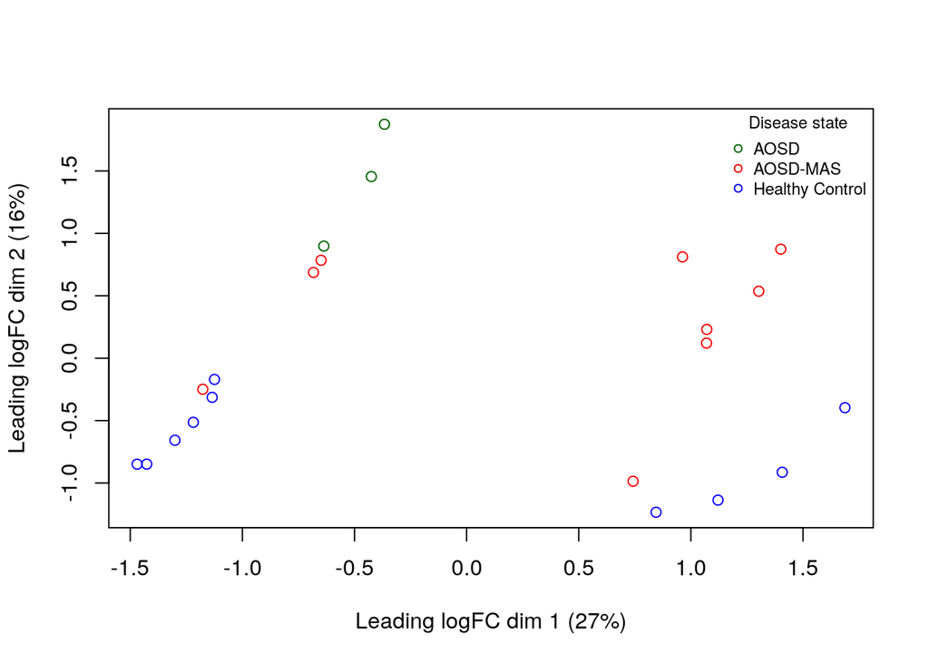

Figure 1. Multidimensional scaling plot by disease state. The disease states are AOSD, AOSD-MAS and healthy control.

```r
#Use the limma package to plot MDS of all samples/patients
limma::plotMDS(d1, labels=NULL, pch = 1,
               col = c("darkgreen","red","blue")[factor(disease_state_1)])
legend("topright",
       legend=levels(factor(disease_state_1)),
       pch=c(1), col = c("darkgreen","red","blue"),title = "Disease state", bty = 'n', cex = 0.75)
```

## 1.1 Model design

From the MDS plot I will chose to use two model designs: 1) only healthy control and AOSD-MAS samples 2) only healthy control and AOSD samples

```r
#Generate a model matrix to design the model for AOSD-MAS vs healthy control
dis_state_AOSDMAS <- c(rep("Healthy Control",10),rep("AOSD-MAS",9))
model_design_AOSDMAS <- model.matrix(~dis_state_AOSDMAS)

#Repeat the above but with the AOSD and healthy control samples
dis_state_AOSD <-  c(rep("Healthy Control",10),rep("AOSD",3))
model_design_AOSD <- model.matrix(~dis_state_AOSD)

#Visual check of the model designs
kable(model_design_AOSDMAS, caption = 'Table 1. Model design for healthy control vs. AOSD-MAS patients' )  %>% kable_styling(bootstrap_options = c("striped", "hover", "condensed", "responsive"))
```

Table 1. Model design for healthy control vs. AOSD-MAS patients

| (Intercept) | dis_state_AOSDMASHealthy Control |
| --- | --- |
| 1 | 1 |
| 1 | 1 |
| 1 | 1 |
| 1 | 1 |
| 1 | 1 |
| 1 | 1 |
| 1 | 1 |
| 1 | 1 |
| 1 | 1 |
| 1 | 1 |
| 1 | 0 |
| 1 | 0 |
| 1 | 0 |
| 1 | 0 |
| 1 | 0 |
| 1 | 0 |
| 1 | 0 |
| 1 | 0 |
| 1 | 0 |

```r
kable(model_design_AOSD, caption = 'Table 2. Model design for healthy control vs. AOSD patients')  %>% kable_styling(bootstrap_options = c("striped", "hover", "condensed", "responsive"))
```

Table 2. Model design for healthy control vs. AOSD patients

| (Intercept) | dis_state_AOSDHealthy Control |
| --- | --- |
| 1 | 1 |
| 1 | 1 |
| 1 | 1 |
| 1 | 1 |
| 1 | 1 |
| 1 | 1 |
| 1 | 1 |
| 1 | 1 |
| 1 | 1 |
| 1 | 1 |
| 1 | 0 |
| 1 | 0 |
| 1 | 0 |

Estimate Dispersion

```r
d1 <- estimateDisp(TMM[, -c(11:13)], model_design_AOSDMAS) #estimate dispersion for model_design_AOSDMAS. Columns 1-10 + 14-22 in TMM (the normalized table of counts)
d2 <- estimateDisp(TMM[, -(14:22)], model_design_AOSD) #estimate dispersion for model_design_AOSD. Columns 1-10 + 14-22 in TMM (the normalized table of counts)
```

Fit the models

```r
#Generate fits for model_design_AOSDMAS and model_design_AOSD which are stored in 'fit1' and 'fit2', respectively
fit1 <- glmQLFit(d1, model_design_AOSDMAS)
fit2 <- glmQLFit(d2, model_design_AOSD)
```

Calculate differential expression using the Quasi likelihood model

```r
#p-value correction was made using the Benjamini and Hochberg procedure which is the default for the `glmQLFTest function`

#calculate differential expression between healthy control and AOSD-MAS using glmQLFTest
qlf.ctrl_vs_AOSDMAS <- glmQLFTest(fit1, coef = ncol(model_design_AOSDMAS))

#calculate differential expression between healthy control and AOSD using glmQLFTest
qlf.ctrl_vs_AOSD <- glmQLFTest(fit2, coef = ncol(model_design_AOSD))
```

Get all the results, sorted by p-value

```r
#sort the above results by p-value
qlf_output_hits_AOSDMAS <- topTags <- topTags(qlf.ctrl_vs_AOSDMAS, sort.by = "PValue", n = nrow(TMM_norm_counts))
qlf_output_hits_AOSD <- topTags <- topTags(qlf.ctrl_vs_AOSD, sort.by = "PValue", n = nrow(TMM_norm_counts))
```

## P-values for genes and multiple hypothesis testing

```r
#How many gene pass the threshold p-value < 0.05?
pval_passed_AOSDMAS <- length(which(qlf_output_hits_AOSDMAS$table$PValue < 0.05))
pval_passed_AOSD <- length(which(qlf_output_hits_AOSD$table$PValue < 0.05))
#how many genes passed FDR correction
FDR_passed_AOSDMAS <- length(which(qlf_output_hits_AOSDMAS$table$FDR < 0.05))
FDR_passed_AOSD <- length(which(qlf_output_hits_AOSD$table$FDR < 0.05))
```

I chose to use p-value < 0.05 as the threshold as it is typically defined as the significance threshold and it is also what is used by the authors in the paper. For the p-value correction I chose the Benjamini and Hochberg (BH) method as opposed to the Bonferroni method because the BH method has more power over the bonferroni method due to the large dataset and the fact that th BH method is less stringent than the Bonferroni method. (“False Discovery Rate | Columbia Public Health,” n.d.)

For the AOSD-MAS comparison to healthy control, there were 3426 which passed the p-value threshold and 988 which passed after FDR correction. Then, for the AOSD comparison to healthy control, there were 4888 which passed the p-value threshold and 3116 which passed after FDR correction.

## 1.2 Volcano plot: Amount of differentially expressed genes

Generate a volcano plot for the healthy control and AOSD-MAS patients

```r
#Make a volcano plot for healthy control vs AOSD-MAS comparison
output_hits_AOSDMAS_df <- as.data.frame(qlf_output_hits_AOSDMAS)

## 1. Add a column to matrix_for_volc called "Differentially_Expressed" to specify if they are up or down regulated
output_hits_AOSDMAS_df$Differentially_Expressed <- "No change" #Set the default to 'No change'
#if logFC > 1 and FDR < 0.05, set as "Up-regulated"
output_hits_AOSDMAS_df$Differentially_Expressed[output_hits_AOSDMAS_df$logFC > 1 & output_hits_AOSDMAS_df$FDR < 0.05] <- "Up-regulated"
#if logFC <-1 and FDR < 0.05, set as "Down-regulated"
output_hits_AOSDMAS_df$Differentially_Expressed[output_hits_AOSDMAS_df$logFC < -1 & output_hits_AOSDMAS_df$FDR < 0.05] <- "Down-regulated"

## 2. Start making a volcano plot
p <- ggplot(data=as.data.frame(output_hits_AOSDMAS_df), aes(x=logFC, y=-log10(FDR), col=Differentially_Expressed)) + geom_point() + theme_minimal()
p2 <- p + geom_vline(xintercept=c(-1, 1), col="blue") +
    geom_hline(yintercept=-log10(0.05), col="red")
p3 <- p2 + scale_color_manual(values=c("blue","grey","red"))

# 3. Assign the colours for downregulated genes, upregulated genes and insignificant genes
mycolors <- c("blue", "red", "grey")
names(mycolors) <- c("Down-regulated", "Up-regulated", "No change")
p3 <- p2 + scale_colour_manual(values = mycolors)
```

Generate a volcano plot for the healthy control and AOSD patients

```r
#Make a volcano plot for healthy control vs AOSD-MAS comparison
output_hits_AOSD_df <- as.data.frame(qlf_output_hits_AOSD)
## 1. Add a column to matrix_for_volc called "Differentially_Expressed" to specify if they are up or down regulated
output_hits_AOSD_df$Differentially_Expressed <- "No change"
#if logFC > 1 and FDR < 0.05, set as "Up-regulated"
output_hits_AOSD_df$Differentially_Expressed[output_hits_AOSD_df$logFC > 1 & output_hits_AOSD_df$FDR < 0.05] <- "Up-regulated"
#if logFC <-1 and FDR < 0.05, set as "Down-regulated"
output_hits_AOSD_df$Differentially_Expressed[output_hits_AOSD_df$logFC < -1 & output_hits_AOSD_df$FDR < 0.05] <- "Down-regulated"

## 2. Start making a volcano plot
p4 <- ggplot(data=as.data.frame(output_hits_AOSD_df), aes(x=logFC, y=-log10(FDR), col=Differentially_Expressed)) + geom_point() + theme_minimal()
p5 <- p4 + geom_vline(xintercept=c(-1, 1), col="blue") +
    geom_hline(yintercept=-log10(0.05), col="red")
p6 <- p5 + scale_color_manual(values=c("blue","grey","red"))

# 3. Assign the colours for downregulated genes, upregulated genes and insignificant genes
mycolors <- c("blue", "red", "grey")
names(mycolors) <- c("Down-regulated", "Up-regulated", "No change")
p6 <- p5 + scale_colour_manual(values = mycolors)
```

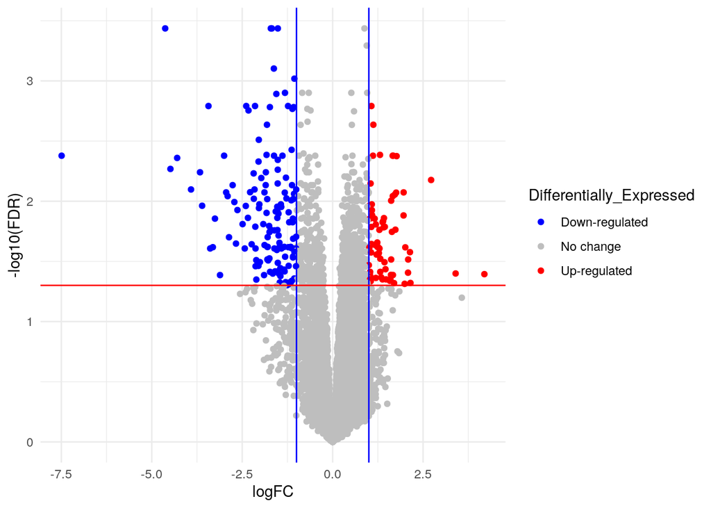

Figure 1. Volcano plot of differentially expressed genes between the healthy control and the AOSD-MAS patients. The fold change (FC) threshold is FC>1 or FC<-1 and the FDR threshold was FDR <0.05

```r
#Visualize the volcano plot of differentially expressed genes between the healthy control and the AOSD-MAS patients
theme_set(theme_pubr()) #setting the theme_pubr as the default theme for the plots
ggarrange(p3, legend =  'right' )
```

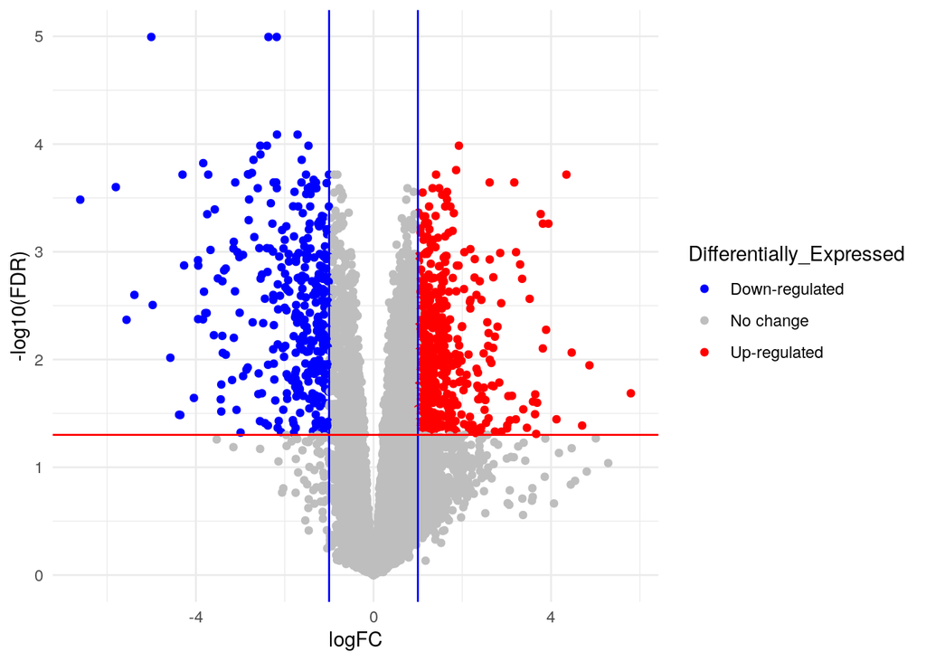

Figure 2. Volcano plot of differentially expressed genes between the healthy control and the AOSD patients. The fold change (FC) threshold is FC>1 or FC<-1 and the FDR threshold was FDR <0.05

```r
#Visualize the volcano plot of differentially expressed genes between the healthy control and the AOSD-MAS patients
theme_set(theme_pubr()) #setting the theme_pubr as the default theme for the plots
ggarrange(p6, legend =  'right' )
```

The fold change threshold here was set to Fold-change>1 or Fold-change<1 like the authors of the paper did.

## 1.3 Heatmap

Make two matrices to generate heatmaps from. One for healthy control vs AOSD-MAS patient and another for healthy control vs AOSD patients

```r
#create two numerical matrices for health control and AOSD-MAS patients and another for healthy control and AOSD patients that we can create heatmaps from
heatmap_matrix_ctrl_AOSDMAS <- TMM_norm_counts[, -c(11:13)] #matrix of normalized counts for samples that are from healthy controls and AOSD-MAS patients
heatmap_matrix_ctrl_AOSD <- TMM_norm_counts[, -(14:22)] #matrix of normalized counts for samples that are from healthy controls and AOSD patients

#Set row names and column names for the matrices we just created
rownames(heatmap_matrix_ctrl_AOSDMAS) <- TMM[["genes"]][["gene_id"]] #add row names to heatmap_matrix_AOSDMAS
colnames(heatmap_matrix_ctrl_AOSDMAS) <- c(paste0('Healthy_Control_',1:10), paste0('AOSD-MAS_', 1:9)) #add column names to heatmap_matrix_AOSDMAS
rownames(heatmap_matrix_ctrl_AOSD) <- TMM[["genes"]][["gene_id"]] #add row names to heatmap_matrix_AOSD
colnames(heatmap_matrix_ctrl_AOSD) <- c(paste0('Healthy_Control_',1:10), paste0('AOSD_', 1:3)) #add column names to heatmap_matrix_AOSD
```

Get the top hit genes for both healthy control vs. AOSD-MAS and healthy control vs. AOSD, defined by FDR < 0.05

```r
#Get names of genes for qlf_output_hits_AOSDMAS (healthy control vs AOSDMAS comparison) that have FDR <0.05
tophits_AOSDMAS <- qlf_output_hits_AOSDMAS$table$gene_id[qlf_output_hits_AOSDMAS$table$FDR<0.05] #get entrez gene id's of those that have FDR < 0.05
heatmap_matrix_tophits_AOSDMAS <- t(
  scale(t(heatmap_matrix_ctrl_AOSDMAS[which(rownames(heatmap_matrix_ctrl_AOSDMAS)
                               %in% tophits_AOSDMAS),]))) #scale each row for those in tophits and centre them around the mean


#Do the same as above but for qlf_output_hits_AOSDMAS (healthy control vs AOSD comparison)
tophits_AOSD <- qlf_output_hits_AOSD$table$gene_id[qlf_output_hits_AOSD$table$FDR<0.05] #get entrez gene id's of those that have FDR < 0.05
heatmap_matrix_tophits_AOSD <- t(
  scale(t(heatmap_matrix_ctrl_AOSD[which(rownames(heatmap_matrix_ctrl_AOSD)
                               %in% tophits_AOSD),]))) #scale each row for those in tophits and centre them around the mean
```

Next, we can generate a function to visualize the heatmap

```r
heatmap_plot <- function(heatmap_matrix_tophits, disease_states){
  if(min(heatmap_matrix_tophits) == 0){
  # testing if there are only positive values
  heatmap_col = colorRamp2(c( 0, max(heatmap_matrix_tophits)),
                           c("white","red"))
}else{
  # if there are both positive and negative
  heatmap_col = colorRamp2(c(min(heatmap_matrix_tophits),0,
                             max(heatmap_matrix_tophits)),
                           c("blue","white","red"))}

  #annotations for heatmap
  #First, define colors for disease_state
  disease_state_color <- rainbow(n=length(unique(disease_states))) #colors for each unique disease state
  names(disease_state_color) <- unique(disease_states) #names of unique disease states
  ha_pat <- HeatmapAnnotation(df = data.frame(disease_state = disease_states),
                              col = list(disease_state = disease_state_color),
                              show_legend = TRUE) #store the heatmap annotation

  #Create heatmap
  current_heatmap <- Heatmap(as.matrix(heatmap_matrix_tophits),
                             top_annotation = ha_pat,
                             cluster_rows = TRUE,
                             cluster_columns = TRUE,
                             show_row_dend = TRUE,
                             show_column_dend = TRUE,
                             col=heatmap_col,
                             show_column_names = FALSE,
                             show_row_names = FALSE,
                             show_heatmap_legend = TRUE,
                             column_title = 'Heatmap of top hits using Quasi likelihood model (p-value < 0.05)')
}
```

```r
#generate the heatmaps using the function heatmap_plot
heatmap_visual_ctrl_vs_AOSDMAS <- heatmap_plot(heatmap_matrix_tophits_AOSDMAS, dis_state_AOSDMAS)
heatmap_visual_ctrl_vs_AOSD <- heatmap_plot(heatmap_matrix_tophits_AOSD, dis_state_AOSD)
```

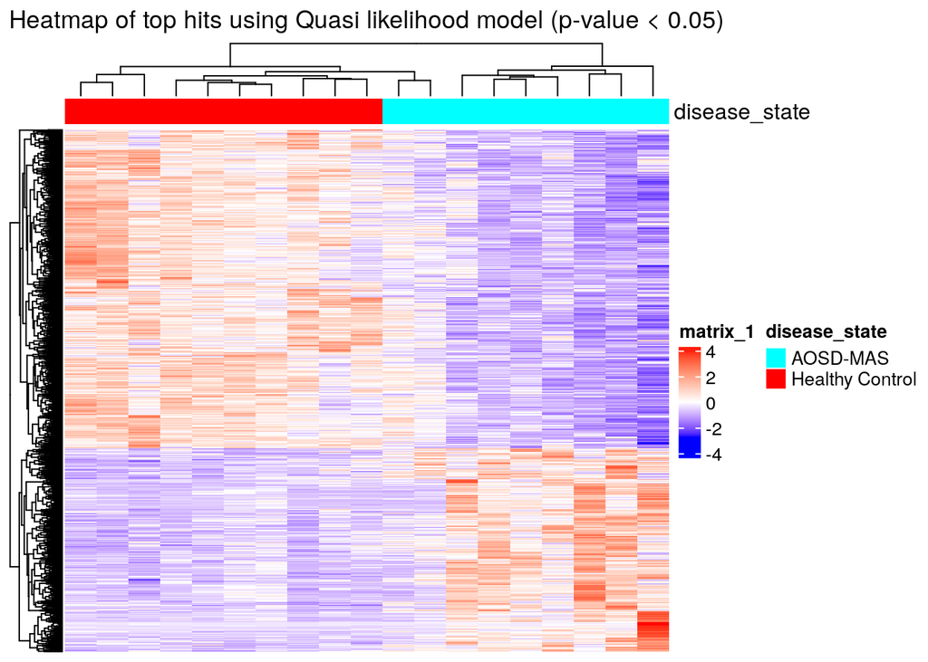

Figure 3. Heatmap of differentially expressed genes between healthy control and AOSD-MAS

```r
heatmap_visual_ctrl_vs_AOSDMAS
```

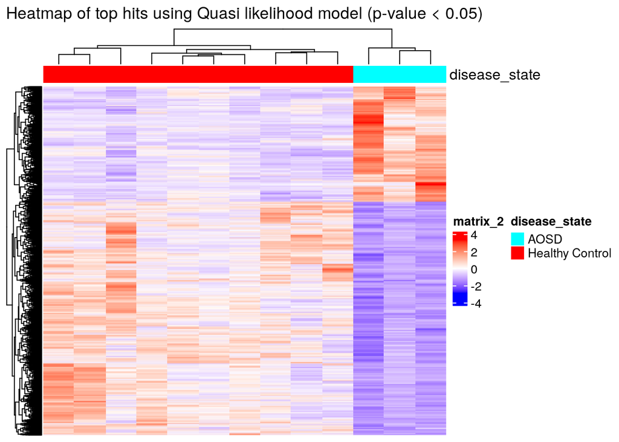

```r
heatmap_visual_ctrl_vs_AOSD
```

For both the heatmaps generated, the samples from the same ‘disease_state’ do cluster together showing that there is differential expression between disease states. This provides evidence that the same sets of genes are either being upregulated or downregulated across samples from the same group.

# Part 2. Thresholded over-representation analysis

Now that we have sets of genes that are significantly up-regulated and down-regulated, we will run a over-representation analysis to see which pathways or terms are enriched.

Store gene id’s of those that are upregulated, downregulated and the full gene list which have FDR<0.05

```r
#Healthy control vs AOSDMAS. Store gene id's of those that are upregulated, downregulated and the full gene list which have FDR<0.05
upreg_AOSDMAS <- output_hits_AOSDMAS_df$gene_symbol[which(output_hits_AOSDMAS_df$logFC > 1 & output_hits_AOSDMAS_df$FDR < 0.05)]
downreg_AOSDMAS <- output_hits_AOSDMAS_df$gene_symbol[which(output_hits_AOSDMAS_df$logFC < -1 & output_hits_AOSDMAS_df$FDR < 0.05)]
full_AOSDMAS <- output_hits_AOSDMAS_df$gene_symbol[which(output_hits_AOSDMAS_df$FDR < 0.05)]

#Healthy control vs AOSD. Store gene id's of those that are upregulated, downregulated and the full gene list which have FDR<0.05
upreg_AOSD <- output_hits_AOSD_df$gene_symbol[which(output_hits_AOSD_df$logFC > 1 & output_hits_AOSD_df$FDR < 0.05)]
downreg_AOSD <- output_hits_AOSD_df$gene_symbol[which(output_hits_AOSD_df$logFC < -1 & output_hits_AOSD_df$FDR < 0.05)]
full_AOSD <- output_hits_AOSD_df$gene_symbol[which(output_hits_AOSD_df$FDR < 0.05)]
```

There were 70 and 142 genes that were upregulated and downregulated, respectively, when comparing AOSD-MAS to control. Furthermore, there were 537 and 346 genes that were upregulated and downregulated, respectively, when comparing AOSD to control

To conduct gene set enrichment analysis on upregulated and downregulated genes and the whole gene set, I will be using the g:profiler R package because it is easy to use.

First, make a function to use the gost g:profiler function which will be used later on.

```r
organism = 'hsapiens'
annot_db = c('GO:BP', 'REAC', 'WP', 'KEGG')

#Make a function to use the gost g:profiler function
gprof_results <- function(gene_list){
  gost(query = gene_list,
                organism = organism, significant = FALSE,
                correction_method = "fdr",
                domain_scope = "annotated",
                numeric_ns = "", sources = annot_db
       ,user_threshold = 0.01)
}

#Use the above function to get results
gprof_up_results_AOSDMAS <- gprof_results(upreg_AOSDMAS)
gprof_down_results_AOSDMAS <- gprof_results(downreg_AOSDMAS)
gprof_whole_results_AOSDMAS <- gprof_results(full_AOSDMAS)

gprof_up_results_AOSD <- gprof_results(upreg_AOSD)
gprof_down_results_AOSD <- gprof_results(downreg_AOSD)
gprof_whole_results_AOSD <- gprof_results(full_AOSD)
```

The annotation sources used here are ‘GO:BP’, ‘REAC’, ‘WP’ as recommended and also ‘KEGG’ as it was used in the author’s paper.

```r
#version of annotation sources
get_version_info(organism='hsapiens')$sources$'GO:BP'$version
```

```
## [1] "annotations: BioMart\nclasses: releases/2024-01-17"
```

```r
get_version_info(organism='hsapiens')$sources$'REAC'$version
```

```
## [1] "annotations: BioMart\nclasses: 2024-1-25"
```

```r
get_version_info(organism='hsapiens')$sources$'WP'$version
```

```
## [1] "20240101"
```

```r
get_version_info(organism='hsapiens')$sources$'KEGG'$version
```

```
## [1] "KEGG FTP Release 2024-01-22"
```

Version of annotation sources: - GO:BP = 2024-01-17

- REAC = 2024-01-25
- WP = 2024-01-01
- KEGG = 2024-01-22

Filter the results by term sizes that are between 5 and 200

```r
#Make a function to filter for term size between 5 and 200
filt_termsize <- function(gprof_results){
  gprof_results$result[which(gprof_results$result$term_size >= 5 & gprof_results$result$term_size <= 200),]
}

#Filter the healthy contrl vs AOSDMAS g:profiler results
up_AOSDMAS_filtered <- filt_termsize(gprof_up_results_AOSDMAS)
down_AOSDMAS_filtered <- filt_termsize(gprof_down_results_AOSDMAS)
whole_AOSDMAS_filtered <- filt_termsize(gprof_whole_results_AOSDMAS)
#Filter the healthy contrl vs AOSD g:profiler results
up_AOSD_filtered <- filt_termsize(gprof_up_results_AOSD)
down_AOSD_filtered <- filt_termsize(gprof_down_results_AOSD)
whole_AOSD_filtered <- filt_termsize(gprof_whole_results_AOSD)
```

Generate a table to view number of genes before and after filtering for healthy control vs AOSD-MAS

```r
gsea_tab_AOSDMAS <- data.frame(Total = c(nrow(gprof_up_results_AOSDMAS$result), nrow(gprof_down_results_AOSDMAS$result), nrow(gprof_whole_results_AOSDMAS$result)), Filtered_results = c(nrow(up_AOSDMAS_filtered),nrow(down_AOSDMAS_filtered),nrow(whole_AOSDMAS_filtered)))

rownames(gsea_tab_AOSDMAS) <- c("Up-regulated","Down-regulated", "Whole gene set")
kable(gsea_tab_AOSDMAS, caption = 'Table 3. Terms returned by over-representation analysis of healthy control and AOSDMAS samples using g:profiler with threshold of 0.01 used.') %>% kable_classic(html_font = "Cambria")
```

|  | Total | Filtered_results |
| --- | --- | --- |
| Up-regulated | 2040 | 1100 |
| Down-regulated | 4135 | 2877 |
| Whole gene set | 9192 | 7327 |

Generate a table to view number of genes before and after filtering for healthy control vs AOSD

```r
gsea_tab_AOSD <- data.frame(Total = c(nrow(gprof_up_results_AOSD$result), nrow(gprof_down_results_AOSD$result), nrow(gprof_whole_results_AOSD$result)), Filtered_results = c(nrow(up_AOSD_filtered),nrow(down_AOSD_filtered),nrow(whole_AOSD_filtered)))

rownames(gsea_tab_AOSD) <- c("Up-regulated","Down-regulated", "Whole gene set")
kable(gsea_tab_AOSD, caption = 'Table 4. Terms returned by gene set enrichment analysis of healthy control and AOSD samples using g:profiler with threshold of 0.01 used.') %>% kable_classic(html_font = "Cambria")
```

|  | Total | Filtered_results |
| --- | --- | --- |
| Up-regulated | 6295 | 4835 |
| Down-regulated | 6486 | 4909 |
| Whole gene set | 12764 | 9658 |

Visualize the top pathway for AOSDMAS genes

```r
#Make a function to generate table for visualizing the
enrich_filt_results <- function(filtered_result){
  col_names <- c('Term Name', 'P-value', 'Term Size', 'Query Size', 'Intersection Size')
  tab_res <- cbind(filtered_result$term_name, filtered_result$p_value,
                   filtered_result$term_size, filtered_result$query_size,
                   filtered_result$intersection_size)
  colnames(tab_res) <- col_names
  tab_res <- as.data.frame(tab_res)
  return(tab_res)
}
```

```r
#Generate tables for the ORA results that have been filtered

#Healthy contrl vs AOSDMAS
tab_up_AOSDMAS_filtered <- enrich_filt_results(up_AOSDMAS_filtered)
tab_down_AOSDMAS_filtered <- enrich_filt_results(down_AOSDMAS_filtered)
tab_whole_AOSDMAS_filtered <- enrich_filt_results(whole_AOSDMAS_filtered)
#Healthy control vs AOSD
tab_up_AOSD_filtered <- enrich_filt_results(up_AOSD_filtered)
tab_down_AOSD_filtered <- enrich_filt_results(down_AOSD_filtered)
tab_whole_AOSD_filtered <- enrich_filt_results(whole_AOSD_filtered)
```

```r
#Table. Terms returned by over-representation analysis of upregulated genes when comparing healthy control to AOSD-MAS
tab_up_AOSDMAS_filtered[1:10,] %>% kable(caption = 'Table 5. Terms returned by over-representation analysis of upregulated genes when comparing healthy control to AOSD-MAS') %>% kable_styling(bootstrap_options = c("striped", "hover", "condensed", "responsive"))
```

Table 5. Terms returned by over-representation analysis of upregulated genes when comparing healthy control to AOSD-MAS

| Term Name | P-value | Term Size | Query Size | Intersection Size |
| --- | --- | --- | --- | --- |
| positive regulation of protein polymerization | 0.000403686047517075 | 91 | 60 | 6 |
| positive regulation of protein-containing complex assembly | 0.00135248613087397 | 199 | 60 | 7 |
| cellular heat acclimation | 0.0174321434515457 | 5 | 60 | 2 |
| antigen processing and presentation, endogenous lipid antigen via MHC class Ib | 0.0174321434515457 | 5 | 60 | 2 |
| heat acclimation | 0.0174321434515457 | 5 | 60 | 2 |
| antigen processing and presentation, exogenous lipid antigen via MHC class Ib | 0.0208417679759887 | 7 | 60 | 2 |
| positive regulation of nucleotide-binding oligomerization domain containing 2 signaling pathway | 0.0208417679759887 | 6 | 60 | 2 |
| antigen processing and presentation of lipid antigen via MHC class Ib | 0.0208417679759887 | 7 | 60 | 2 |
| microtubule polymerization | 0.0208417679759887 | 95 | 60 | 4 |
| positive regulation of nucleotide-binding domain, leucine rich repeat containing receptor signaling pathway | 0.0208417679759887 | 7 | 60 | 2 |

```r
#Table. Terms returned by over-representation analysis of downregulated genes when comparing healthy control to AOSD-MAS
tab_down_AOSDMAS_filtered[1:40,] %>% kable(caption = 'Table 6. Terms returned by over-representation analysis of downregulated genes when comparing healthy control to AOSD-MAS') %>% kable_styling(bootstrap_options = c("striped", "hover", "condensed", "responsive"))
```

Table 6. Terms returned by over-representation analysis of downregulated genes when comparing healthy control to AOSD-MAS

| Term Name | P-value | Term Size | Query Size | Intersection Size |
| --- | --- | --- | --- | --- |
| interferon-mediated signaling pathway | 9.71996406977763e-08 | 106 | 130 | 10 |
| response to type II interferon | 1.43571794153252e-07 | 146 | 130 | 11 |
| type I interferon-mediated signaling pathway | 2.59863814789263e-06 | 81 | 130 | 8 |
| cellular response to type I interferon | 2.80379257883407e-06 | 82 | 130 | 8 |
| negative regulation of viral genome replication | 3.06179983128344e-06 | 55 | 130 | 7 |
| response to type I interferon | 4.3716313021211e-06 | 88 | 130 | 8 |
| viral genome replication | 5.87761422860349e-06 | 128 | 130 | 9 |
| negative regulation of viral process | 7.37277037852956e-06 | 95 | 130 | 8 |
| complement activation, classical pathway | 9.85915798174084e-06 | 41 | 130 | 6 |
| regulation of viral genome replication | 4.03398074733103e-05 | 85 | 130 | 7 |
| regulation of viral process | 4.44313538936849e-05 | 169 | 130 | 9 |
| humoral immune response mediated by circulating immunoglobulin | 4.55561891392037e-05 | 55 | 130 | 6 |
| response to interferon-beta | 7.6353762099607e-05 | 34 | 130 | 5 |
| fusion of virus membrane with host plasma membrane | 8.22051253748984e-05 | 5 | 130 | 3 |
| membrane fusion involved in viral entry into host cell | 8.22051253748984e-05 | 5 | 130 | 3 |
| positive regulation of pyroptosis | 8.22051253748984e-05 | 5 | 130 | 3 |
| pyroptosis | 8.30451046344642e-05 | 35 | 130 | 5 |
| complement activation | 9.65010206174047e-05 | 64 | 130 | 6 |
| regulation of viral life cycle | 0.000111974967515576 | 145 | 130 | 8 |
| AIM2 inflammasome complex assembly | 0.000145480818940515 | 6 | 130 | 3 |
| cytolysis in another organism | 0.000145480818940515 | 6 | 130 | 3 |
| response to interferon-alpha | 0.000186624098206373 | 20 | 130 | 4 |
| response to nutrient | 0.000271963864593613 | 167 | 130 | 8 |
| negative regulation of innate immune response | 0.000331446123294826 | 82 | 130 | 6 |
| cellular response to type II interferon | 0.000336027466152169 | 124 | 130 | 7 |
| cytolysis | 0.000347505303183859 | 8 | 130 | 3 |
| antiviral innate immune response | 0.000405015892587652 | 51 | 130 | 5 |
| regulation of adaptive immune response based on somatic recombination of immune receptors built from immunoglobulin superfamily domains | 0.000548568984332062 | 187 | 130 | 8 |
| defense response to protozoan | 0.000549950032153669 | 27 | 130 | 4 |
| positive regulation of inflammatory response | 0.000694305057547886 | 141 | 130 | 7 |
| response to protozoan | 0.000826838361973642 | 30 | 130 | 4 |
| macrophage activation | 0.00116812893786498 | 106 | 130 | 6 |
| positive regulation of pattern recognition receptor signaling pathway | 0.00116812893786498 | 65 | 130 | 5 |
| symbiont entry into host cell | 0.00119306397133365 | 156 | 130 | 7 |
| cytoplasmic pattern recognition receptor signaling pathway | 0.00119306397133365 | 156 | 130 | 7 |
| positive regulation of defense response to virus by host | 0.00124702603657095 | 34 | 130 | 4 |
| branching involved in labyrinthine layer morphogenesis | 0.00137603444420499 | 13 | 130 | 3 |
| negative regulation of response to biotic stimulus | 0.00150692960264157 | 112 | 130 | 6 |
| symbiont entry into host | 0.00151041194727064 | 163 | 130 | 7 |
| synapse pruning | 0.00168529135588125 | 14 | 130 | 3 |

```r
#Table. Terms returned by over-representation analysis of genes when comparing healthy control to AOSD-MAS
tab_whole_AOSDMAS_filtered[1:10,] %>% kable(caption = 'Table 7. Terms returned by over-representation analysis of genes when comparing healthy control to AOSD-MAS') %>% kable_styling(bootstrap_options = c("striped", "hover", "condensed", "responsive"))
```

Table 7. Terms returned by over-representation analysis of genes when comparing healthy control to AOSD-MAS

| Term Name | P-value | Term Size | Query Size | Intersection Size |
| --- | --- | --- | --- | --- |
| cytoplasmic translation | 1.52205888825087e-05 | 156 | 896 | 23 |
| regulation of defense response to virus by host | 2.34324187321295e-05 | 46 | 896 | 12 |
| positive regulation of pattern recognition receptor signaling pathway | 3.13392840182189e-05 | 65 | 896 | 14 |
| cytoplasmic pattern recognition receptor signaling pathway | 5.1195006345937e-05 | 156 | 896 | 22 |
| positive regulation of defense response to virus by host | 5.96327465173607e-05 | 34 | 896 | 10 |
| regulation of adaptive immune response based on somatic recombination of immune receptors built from immunoglobulin superfamily domains | 8.5563124988819e-05 | 187 | 896 | 24 |
| viral genome replication | 0.000115541910616302 | 128 | 896 | 19 |
| interferon-mediated signaling pathway | 0.000131395176401968 | 106 | 896 | 17 |
| regulation of pattern recognition receptor signaling pathway | 0.000321296213678374 | 151 | 896 | 20 |
| positive regulation of inflammatory response | 0.000410254598525507 | 141 | 896 | 19 |

```r
#Table. Terms returned by over-representation analysis of upregulated genes when comparing healthy control to AOSD
tab_up_AOSD_filtered[1:10,] %>% kable(caption = 'Table 8. Terms returned by over-representation analysis of upregulated genes when comparing healthy control to AOSD') %>% kable_styling(bootstrap_options = c("striped", "hover", "condensed", "responsive"))
```

Table 8. Terms returned by over-representation analysis of upregulated genes when comparing healthy control to AOSD

| Term Name | P-value | Term Size | Query Size | Intersection Size |
| --- | --- | --- | --- | --- |
| neuron projection extension | 0.00048861823545398 | 180 | 464 | 16 |
| dichotomous subdivision of an epithelial terminal unit | 0.00169681716853454 | 8 | 464 | 4 |
| axon extension | 0.00201708098780004 | 124 | 464 | 12 |
| regulation of axonogenesis | 0.00382896672715444 | 158 | 464 | 13 |
| semaphorin-plexin signaling pathway | 0.00473495085504279 | 47 | 464 | 7 |
| branching involved in salivary gland morphogenesis | 0.00613269224587279 | 22 | 464 | 5 |
| gonadotrophin-releasing hormone neuronal migration to the hypothalamus | 0.0114228867192522 | 6 | 464 | 3 |
| hypothalamic tangential migration using cell-axon interactions | 0.0114228867192522 | 6 | 464 | 3 |
| positive regulation of dendritic spine development | 0.0124042457013652 | 40 | 464 | 6 |
| dendritic spine development | 0.0168882768207521 | 98 | 464 | 9 |

```r
#Table. Terms returned by over-representation analysis of downregulated genes when comparing healthy control to AOSD
tab_down_AOSD_filtered[1:10,] %>% kable(caption = 'Table 9. Terms returned by over-representation analysis of downregulated genes when comparing healthy control to AOSD') %>% kable_styling(bootstrap_options = c("striped", "hover", "condensed", "responsive"))
```

Table 9. Terms returned by over-representation analysis of downregulated genes when comparing healthy control to AOSD

| Term Name | P-value | Term Size | Query Size | Intersection Size |
| --- | --- | --- | --- | --- |
| negative regulation of viral process | 9.04831143648152e-11 | 95 | 316 | 16 |
| negative regulation of viral genome replication | 1.24624323987386e-10 | 55 | 316 | 13 |
| interferon-mediated signaling pathway | 4.45251474609354e-10 | 106 | 316 | 16 |
| response to type II interferon | 6.39458832421028e-10 | 146 | 316 | 18 |
| viral genome replication | 6.67274416352654e-09 | 128 | 316 | 16 |
| regulation of viral process | 6.67274416352654e-09 | 169 | 316 | 18 |
| negative regulation of innate immune response | 1.87608977562649e-08 | 82 | 316 | 13 |
| positive regulation of inflammatory response | 2.65849995146809e-08 | 141 | 316 | 16 |
| regulation of viral genome replication | 2.78781324574062e-08 | 85 | 316 | 13 |
| negative regulation of immune response | 3.3966077851531e-08 | 188 | 316 | 18 |

```r
#Table. Terms returned by over-representation analysis of downregulated genes when comparing healthy control to AOSD
tab_whole_AOSD_filtered[1:40,] %>% kable(caption = 'Table 10.  Terms returned by over-representation analysis of genes when comparing healthy control to AOSD') %>% kable_styling(bootstrap_options = c("striped", "hover", "condensed", "responsive"))
```

Table 10. Terms returned by over-representation analysis of genes when comparing healthy control to AOSD

| Term Name | P-value | Term Size | Query Size | Intersection Size |
| --- | --- | --- | --- | --- |
| cytoplasmic translation | 2.40592840844307e-44 | 156 | 2799 | 99 |
| regulation of viral process | 7.60536438665921e-10 | 169 | 2799 | 57 |
| ribosomal small subunit biogenesis | 1.39971314666973e-08 | 101 | 2799 | 39 |
| interferon-mediated signaling pathway | 1.81757924273775e-08 | 106 | 2799 | 40 |
| regulation of viral genome replication | 6.04419755862485e-08 | 85 | 2799 | 34 |
| regulation of viral life cycle | 1.62411205135108e-07 | 145 | 2799 | 47 |
| viral genome replication | 2.22998966256977e-07 | 128 | 2799 | 43 |
| cellular response to type I interferon | 3.47380293373108e-07 | 82 | 2799 | 32 |
| negative regulation of viral process | 3.93855052015198e-07 | 95 | 2799 | 35 |
| tRNA modification | 3.93855052015198e-07 | 95 | 2799 | 35 |
| negative regulation of viral genome replication | 3.93987038608431e-07 | 55 | 2799 | 25 |
| response to type I interferon | 6.27420029952205e-07 | 88 | 2799 | 33 |
| type I interferon-mediated signaling pathway | 9.69460021384118e-07 | 81 | 2799 | 31 |
| ribosomal large subunit biogenesis | 2.01157403505828e-06 | 75 | 2799 | 29 |
| negative regulation of transferase activity | 8.41412532099711e-06 | 194 | 2799 | 53 |
| regulation of response to cytokine stimulus | 8.78263156641511e-06 | 169 | 2799 | 48 |
| tRNA processing | 1.4092903547046e-05 | 137 | 2799 | 41 |
| regulation of cytokine-mediated signaling pathway | 1.79766190366831e-05 | 158 | 2799 | 45 |
| antiviral innate immune response | 3.61548901817719e-05 | 51 | 2799 | 21 |
| positive regulation of type I interferon production | 5.05687553286974e-05 | 73 | 2799 | 26 |
| signal transduction by p53 class mediator | 6.60241371444359e-05 | 181 | 2799 | 48 |
| symbiont entry into host cell | 7.55096638177016e-05 | 156 | 2799 | 43 |
| response to interferon-beta | 8.13050925374272e-05 | 34 | 2799 | 16 |
| symbiont entry into host | 0.000102788894780636 | 163 | 2799 | 44 |
| negative regulation of translation | 0.000109221715639263 | 128 | 2799 | 37 |
| RNA modification | 0.000169831078542864 | 182 | 2799 | 47 |
| cytoplasmic pattern recognition receptor signaling pathway | 0.000173218515284011 | 156 | 2799 | 42 |
| negative regulation of amide metabolic process | 0.000177359967032882 | 151 | 2799 | 41 |
| regulation of nucleocytoplasmic transport | 0.00018503774182475 | 116 | 2799 | 34 |
| regulation of type I interferon production | 0.000221680796778473 | 122 | 2799 | 35 |
| type I interferon production | 0.000221680796778473 | 122 | 2799 | 35 |
| negative regulation of kinase activity | 0.000266392951519757 | 159 | 2799 | 42 |
| regulation of RNA splicing | 0.000287653184037953 | 186 | 2799 | 47 |
| regulation of defense response to virus by host | 0.0003761846847158 | 46 | 2799 | 18 |
| peptide antigen assembly with MHC protein complex | 0.000452269117111793 | 17 | 2799 | 10 |
| MHC protein complex assembly | 0.000452269117111793 | 17 | 2799 | 10 |
| antigen processing and presentation of exogenous antigen | 0.000516670285394418 | 47 | 2799 | 18 |
| positive regulation of interleukin-1 beta production | 0.000530230343066939 | 60 | 2799 | 21 |
| pyroptosis | 0.000534018367233501 | 35 | 2799 | 15 |
| regulation of type I interferon-mediated signaling pathway | 0.000535967105873204 | 43 | 2799 | 17 |

For the comparison between healthy controls and AOSD, most of the terms from the upregulated genes were related to axonogenesis and dendritic spine development, and the terms returned from the downregulated genes were related to negative regulation of immune responses. Once again, most of the results from Table 10. corresponds to the terms returns by the downregulated genes which are immune response related.

# Interpretation

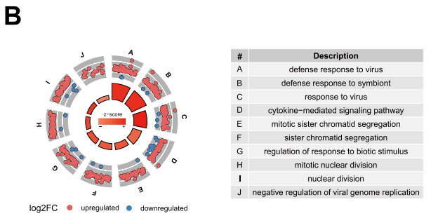

Figure 5. GO analysis done by Jie et al 2023 of Differentially expressed genes of AOSD-MAS versus HCs.(Jia et al. 2023)

## Q2. Can you find evidence, i.e. publications, to support some of the results that you see. How does this evidence support your results

Yes, there has been many sources of evidence showing the role of the innate system activation during the pathogenesis of AOSD. One publication has shown that macrophages and neutrophils initate and facilitate inflammation in patients with AOSD.(Wang et al. 2019) Another group has also shown that the activated monocytes migrate and accumulate in tissues and differentiate into pro-inflammatory macrophages.(Billiau et al. 2005) These publications further support the findings in this assignment that the there is an increased immune response associated with activated monocytes in AOSD patients with and without MAS.

# References

Billiau, An D., Tania Roskams, Rita Van Damme-Lombaerts, Patrick Matthys, and Carine Wouters. 2005. “Macrophage Activation Syndrome: Characteristic Findings on Liver Biopsy Illustrating the Key Role of Activated, IFN-Gamma-Producing Lymphocytes and IL-6- and TNF-Alpha-Producing Macrophages.” *Blood* 105 (February): 1648–51. https://doi.org/10.1182/blood-2004-08-2997.

Chen, Yunshun, Aaron A T Lun, and Gordon K Smyth. 2016. “From Reads to Genes to Pathways: Differential Expression Analysis of RNA-Seq Experiments Using Rsubread and the edgeR Quasi-Likelihood Pipeline.” *F1000Research* 5: 1438. https://doi.org/10.12688/f1000research.8987.2.

Cheng, Joe, Carson Sievert, Barret Schloerke, Winston Chang, Yihui Xie, and Jeff Allen. 2023. *Htmltools: Tools for HTML*. https://github.com/rstudio/htmltools.

“False Discovery Rate | Columbia Public Health.” n.d. www.publichealth.columbia.edu. https://www.publichealth.columbia.edu/research/population-health-methods/false-discovery-rate.

Gu, Zuguang. 2022. *colorRamp2: Generate Color Mapping Functions*. https://github.com/jokergoo/colorRamp2.

Gu, Zuguang, Roland Eils, and Matthias Schlesner. 2016. “Complex Heatmaps Reveal Patterns and Correlations in Multidimensional Genomic Data.” *Bioinformatics*. https://doi.org/10.1093/bioinformatics/btw313.

Gu, Zuguang, Lei Gu, Roland Eils, Matthias Schlesner, and Benedikt Brors. 2014. “Circlize Implements and Enhances Circular Visualization in r.” *Bioinformatics* 30: 2811–12.

Hu, Qiongyi, Jinchao Jia, and Mengyan Wang. 2023. “Monocyte Gene Expression in Adult-Onset Still’s Disease.” www.ncbi.nlm.nih.gov. https://www.ncbi.nlm.nih.gov/geo/query/acc.cgi?acc=GSE247993.

Jia, Jinchao, Mengyan Wang, Yuning Ma, Jianfen Meng, Dehao Zhu, Xia Chen, Hui Shi, et al. 2023. “Neutrophil Extracellular Trap-Induced Intermediate Monocytes Trigger Macrophage Activation Syndrome in Adult-Onset Still’s Disease.” *BMC Medicine* 21 (December). https://doi.org/10.1186/s12916-023-03231-9.

Kassambara, Alboukadel. 2023. *Ggpubr: ’Ggplot2’ Based Publication Ready Plots*. https://rpkgs.datanovia.com/ggpubr/.

Kolberg, Liis, Uku Raudvere, Ivan Kuzmin, Jaak Vilo, and Hedi Peterson. 2020. “Gprofiler2– an r Package for Gene List Functional Enrichment Analysis and Namespace Conversion Toolset g:profiler.” *F1000Research* 9 (ELIXIR) (709).

Slowikowski, Kamil. 2024. *Ggrepel: Automatically Position Non-Overlapping Text Labels with ’Ggplot2’*. https://ggrepel.slowkow.com/.

Wang, Meng-Yan, Jin-Chao Jia, Cheng-De Yang, and Qiong-Yi Hu. 2019. “Pathogenesis, Disease Course, and Prognosis of Adult-Onset Still’s Disease: An Update and Review.” *Chinese Medical Journal* 132 (November): 2856–64. https://doi.org/10.1097/cm9.0000000000000538.

Wickham, Hadley. 2016. *Ggplot2: Elegant Graphics for Data Analysis*. Springer-Verlag New York. https://ggplot2.tidyverse.org.

Wickham, Hadley, Romain François, Lionel Henry, Kirill Müller, and Davis Vaughan. 2023. *Dplyr: A Grammar of Data Manipulation*. https://CRAN.R-project.org/package=dplyr.

Xie, Yihui. 2023. *Knitr: A General-Purpose Package for Dynamic Report Generation in r*. https://yihui.org/knitr/.

Zhu, Hao. 2021. *kableExtra: Construct Complex Table with ’Kable’ and Pipe Syntax*. http://haozhu233.github.io/kableExtra/.